# Project 1: Impact of Race/Ethnicity and State Education Level on Hate Crimes and Police Killing

SDS322E

## Data Wrangling, Exploration, Visualization

### Yuxuan Zhuang yz24574

#### Introduction

##### The data used in this project was sourced from two datasets: “hate_crimes” and “police_killings” in the R Package “fivethirtyeight.”

##### The definition of hate crime is a prejudice-motivated crime which occurs when a perpetrator attacks a victim because of the victim’s (perceived) membership of a certain social group or racial demographic. Hate crimes increased after the 2016 election, according to the Southern Poverty Law Center, there were about 90 hate crimes per day in the first 10 days after the election. By comparison, about 36,000 hate crimes were reported to the FBI from 2010 through 2015 — an average of 16 per day. On the other hand, there were 467 cases of police killing in the year of 2015, which is another notable and debatable social issue.

##### As a student of social science, I am interested in the social factors that are responsible or/and have the potential of causing both hate crimes and police killing. To be specific, this project will focus on what roles race/ethnicity and state education level play in the police killing incidence, and whether there is an association between hate crimes and police killing.

```r
library(fivethirtyeight)
colnames(hate_crimes)
```

```
##  [1] "state"                       "state_abbrev"
##  [3] "median_house_inc"            "share_unemp_seas"
##  [5] "share_pop_metro"             "share_pop_hs"
##  [7] "share_non_citizen"           "share_white_poverty"
##  [9] "gini_index"                  "share_non_white"
## [11] "share_vote_trump"            "hate_crimes_per_100k_splc"
## [13] "avg_hatecrimes_per_100k_fbi"
```

```r
colnames(police_killings)
```

```
##  [1] "name"                 "age"                  "gender"
##  [4] "raceethnicity"        "month"                "day"
##  [7] "year"                 "streetaddress"        "city"
## [10] "state"                "latitude"             "longitude"
## [13] "state_fp"             "county_fp"            "tract_ce"
## [16] "geo_id"               "county_id"            "namelsad"
## [19] "lawenforcementagency" "cause"                "armed"
## [22] "pop"                  "share_white"          "share_black"
## [25] "share_hispanic"       "p_income"             "h_income"
## [28] "county_income"        "comp_income"          "county_bucket"
## [31] "nat_bucket"           "pov"                  "urate"
## [34] "college"
```

```r
head(hate_crimes)
```

```
##        state state_abbrev median_house_inc share_unemp_seas share_pop_metro
## 1    Alabama           AL            42278            0.060            0.64
## 2     Alaska           AK            67629            0.064            0.63
## 3    Arizona           AZ            49254            0.063            0.90
## 4   Arkansas           AR            44922            0.052            0.69
## 5 California           CA            60487            0.059            0.97
## 6   Colorado           CO            60940            0.040            0.80
##   share_pop_hs share_non_citizen share_white_poverty gini_index share_non_white
## 1        0.821              0.02                0.12      0.472            0.35
## 2        0.914              0.04                0.06      0.422            0.42
## 3        0.842              0.10                0.09      0.455            0.49
## 4        0.824              0.04                0.12      0.458            0.26
## 5        0.806              0.13                0.09      0.471            0.61
## 6        0.893              0.06                0.07      0.457            0.31
##   share_vote_trump hate_crimes_per_100k_splc avg_hatecrimes_per_100k_fbi
## 1             0.63                0.12583893                   1.8064105
## 2             0.53                0.14374012                   1.6567001
## 3             0.50                0.22531995                   3.4139280
## 4             0.60                0.06906077                   0.8692089
## 5             0.33                0.25580536                   2.3979859
## 6             0.44                0.39052330                   2.8046888
```

```r
head(police_killings)
```

```
##                 name age gender raceethnicity    month day year
## 1 A'donte Washington  16   Male         Black February  23 2015
## 2     Aaron Rutledge  27   Male         White    April   2 2015
##            streetaddress      city state latitude longitude state_fp county_fp
## 1           Clearview Ln Millbrook    AL 32.52958 -86.36283        1        51
## 2 300 block Iris Park Dr Pineville    LA 31.32174 -92.43486       22        79
##   tract_ce      geo_id county_id            namelsad
## 1    30902  1051030902      1051 Census Tract 309.02
## 2    11700 22079011700     22079    Census Tract 117
##              lawenforcementagency   cause armed  pop share_white share_black
## 1     Millbrook Police Department Gunshot    No 3779        60.5        30.5
## 2 Rapides Parish Sheriff's Office Gunshot    No 2769        53.8        36.2
##   share_hispanic p_income h_income county_income comp_income county_bucket
## 1            5.6    28375    51367         54766   0.9379359             3
## 2            0.5    14678    27972         40930   0.6834107             2
##   nat_bucket  pov      urate   college
## 1          3 14.1 0.09768638 0.1685095
## 2          1 28.8 0.06572379 0.1114024
##  [ reached 'max' / getOption("max.print") -- omitted 4 rows ]
```

##### The dataset “hate_crimes” is the raw data behind the article “Higher Rates of Hate Crimes were Tied to Income Inequality” published in 2017. This is the link of that article: https://fivethirtyeight.com/features/higher-rates-of-hate-crimes-are-tied-to-income-inequality/. There are 13 variables with 51 rows representing US states and DC in the dataset.

There are 2 outcome variables, ‘hate_crimes_per_100k_splc’ and ‘avg_hatecrimes_per_100k_fbi.’

```
'hate_crimes_per_100k_splc' indicates hate crimes per 100,000 population, sourced from Southern Poverty Law Center in Nov. 9-18, 2016.
'avg_hatecrimes_per_100k_fbi' indicates average annual hate crimes per 100,000 population, sourced from FBI from 2010-2015.
```

There are 11 factor variables that can be separated into 4 categories: (1) location, (2) income level / employment status, (3) education level, and (4) other demographic information.

```
1.1 'state': State name
1.2 'state_abbrev': State abbreviation
2.1 'median_house_inc': Median household income in 2016
2.2 'share_unemp_seas': Share of the population that is unemployed (seasonally adjusted) in Sep 2016
2.3 'share_white_poverty': Share of white residents who are living in poverty in 2015
2.4 'gini_index': Gini Index in 2015
3.1 'share_pop_hs': Share of adults 25 and older with a high-school degree in 2009
4.1 'share_pop_metro': Share of the population that lives in metropolitan areas in 2015
4.2 'share_non_citizen': Share of the population that are not U.S. citizens in 2015
4.3 'share_non_white': Share of the population that is not white in 2015
4.4 'share_vote_trump': Share of 2016 U.S. presidential voters who voted for Donald Trump
```

##### The dataset “police_killings” is the raw data behind the article “Where Police Have Killed Americans In 2015” published in 2015. This is the link of that article: https://fivethirtyeight.com/features/where-police-have-killed-americans-in-2015/. In the dataset, there are 34 variables with 467 rows representing people who died from interactions with plolice in the year of 2015.

Below are variables of interest (15 out of 34).

```
‘gender’：Gender of deceased
‘raceethnicity’：Race/ethnicity of deceased
‘state’： State where incident occurred
'share_white': Share of pop that is non-Hispanic white
'share_black': Share of pop that is black (alone, not in combination)
'share_hispanic': Share of pop that is Hispanic/Latino (any race)
'p_income': Tract-level median personal income
'h_income': Tract-level median household income
'county_income': County-level median household income
'comp_income': 'h_income' / 'county_income'
'county_bucket': Household income, quintile within county
'nat_bucket': Household income, quintile nationally
'pov': Tract-level poverty rate (official)
'urate': Tract-level unemployment rate
'college': Share of 25+ pop with BA or higher
```

#### Tidying: Reshaping

Both “hate_crimes” and “police_killings” datasets are already tidy. The data reshaping below are performing the processes of untidying (using pivot_longer) and then retidying (using pivot_wider).

```r
library(tidyr)
library(dplyr)
hate_crimes %>% pivot_longer(3:13, names_to = "factor", values_to = "value") %>%
    head(12)
```

```
## # A tibble: 12 × 4
##    state   state_abbrev factor                          value
##    <chr>   <chr>        <chr>                           <dbl>
##  1 Alabama AL           median_house_inc            42278
##  2 Alabama AL           share_unemp_seas                0.06
##  3 Alabama AL           share_pop_metro                 0.64
##  4 Alabama AL           share_pop_hs                    0.821
##  5 Alabama AL           share_non_citizen               0.02
##  6 Alabama AL           share_white_poverty             0.12
##  7 Alabama AL           gini_index                      0.472
##  8 Alabama AL           share_non_white                 0.35
##  9 Alabama AL           share_vote_trump                0.63
## 10 Alabama AL           hate_crimes_per_100k_splc       0.126
## 11 Alabama AL           avg_hatecrimes_per_100k_fbi     1.81
## 12 Alaska  AK           median_house_inc            67629
```

```r
untidy_hate_crime_1 <- hate_crimes %>% pivot_longer(3:13, names_to = "factor",
    values_to = "value")
untidy_hate_crime_1 %>% pivot_wider(names_from = "factor", values_from = "value")
```

```
## # A tibble: 51 × 13
##    state          state_abbrev median_house_inc share_unemp_seas share_pop_metro
##    <chr>          <chr>                   <dbl>            <dbl>           <dbl>
##  1 Alabama        AL                      42278            0.06             0.64
##  2 Alaska         AK                      67629            0.064            0.63
##  3 Arizona        AZ                      49254            0.063            0.9
##  4 Arkansas       AR                      44922            0.052            0.69
##  5 California     CA                      60487            0.059            0.97
##  6 Colorado       CO                      60940            0.04             0.8
##  7 Connecticut    CT                      70161            0.052            0.94
##  8 Delaware       DE                      57522            0.049            0.9
##  9 District of C… DC                      68277            0.067            1
## 10 Florida        FL                      46140            0.052            0.96
## # … with 41 more rows, and 8 more variables: share_pop_hs <dbl>,
## #   share_non_citizen <dbl>, share_white_poverty <dbl>, gini_index <dbl>,
## #   share_non_white <dbl>, share_vote_trump <dbl>,
## #   hate_crimes_per_100k_splc <dbl>, avg_hatecrimes_per_100k_fbi <dbl>
```

```r
police_killings %>% pivot_longer(26:30, names_to = "income",
    values_to = "value") %>% select(c(1, 30:31)) %>% head(6)
```

```
## # A tibble: 6 × 3
##   name               income            value
##   <chr>              <chr>             <dbl>
## 1 A'donte Washington p_income      28375
## 2 A'donte Washington h_income      51367
## 3 A'donte Washington county_income 54766
## 4 A'donte Washington comp_income       0.938
## 5 A'donte Washington county_bucket     3
## 6 Aaron Rutledge     p_income      14678
```

```r
untidy_police_killings_1 <- police_killings %>% pivot_longer(26:30,
    names_to = "income", values_to = "value")
untidy_police_killings_1 %>% pivot_wider(names_from = "income",
    values_from = "value")
```

```
## # A tibble: 467 × 34
##    name     age gender raceethnicity month   day  year streetaddress city  state
##    <chr>  <int> <chr>  <chr>         <chr> <int> <int> <chr>         <chr> <chr>
##  1 A'don…    16 Male   Black         Febr…    23  2015 Clearview Ln  Mill… AL
##  2 Aaron…    27 Male   White         April     2  2015 300 block Ir… Pine… LA
##  3 Aaron…    26 Male   White         March    14  2015 22nd Ave and… Keno… WI
##  4 Aaron…    25 Male   Hispanic/Lat… March    11  2015 3000 Seminol… Sout… CA
##  5 Adam …    29 Male   White         March    19  2015 364 Hiwood A… Munr… OH
##  6 Adam …    29 Male   White         March     7  2015 18th St and … Phoe… AZ
##  7 Adria…    22 Male   Hispanic/Lat… March    27  2015 4000 Union A… Bake… CA
##  8 Adria…    35 Male   Hispanic/Lat… March    26  2015 1500 Bayview… Wilm… CA
##  9 Alan …    44 Male   White         Janu…    28  2015 Pickett Runn… Suns… TX
## 10 Alan …    31 Male   White         Febr…     7  2015 200 Abbie St… Wyom… MI
## # … with 457 more rows, and 24 more variables: latitude <dbl>, longitude <dbl>,
## #   state_fp <int>, county_fp <int>, tract_ce <int>, geo_id <dbl>,
## #   county_id <int>, namelsad <chr>, lawenforcementagency <chr>, cause <chr>,
## #   armed <chr>, pop <int>, share_white <dbl>, share_black <dbl>,
## #   share_hispanic <dbl>, nat_bucket <int>, pov <dbl>, urate <dbl>,
## #   college <dbl>, p_income <dbl>, h_income <dbl>, county_income <dbl>,
## #   comp_income <dbl>, county_bucket <dbl>
```

#### Joining/Merging

```r
police_killings %>% inner_join(hate_crimes, by = c(state = "state_abbrev"),
    suffix = c(".abbrev", ".full_name"))
```

```
## # A tibble: 467 × 46
##    name     age gender raceethnicity month   day  year streetaddress city  state
##    <chr>  <int> <chr>  <chr>         <chr> <int> <int> <chr>         <chr> <chr>
##  1 A'don…    16 Male   Black         Febr…    23  2015 Clearview Ln  Mill… AL
##  2 Aaron…    27 Male   White         April     2  2015 300 block Ir… Pine… LA
##  3 Aaron…    26 Male   White         March    14  2015 22nd Ave and… Keno… WI
##  4 Aaron…    25 Male   Hispanic/Lat… March    11  2015 3000 Seminol… Sout… CA
##  5 Adam …    29 Male   White         March    19  2015 364 Hiwood A… Munr… OH
##  6 Adam …    29 Male   White         March     7  2015 18th St and … Phoe… AZ
##  7 Adria…    22 Male   Hispanic/Lat… March    27  2015 4000 Union A… Bake… CA
##  8 Adria…    35 Male   Hispanic/Lat… March    26  2015 1500 Bayview… Wilm… CA
##  9 Alan …    44 Male   White         Janu…    28  2015 Pickett Runn… Suns… TX
## 10 Alan …    31 Male   White         Febr…     7  2015 200 Abbie St… Wyom… MI
## # … with 457 more rows, and 36 more variables: latitude <dbl>, longitude <dbl>,
## #   state_fp <int>, county_fp <int>, tract_ce <int>, geo_id <dbl>,
## #   county_id <int>, namelsad <chr>, lawenforcementagency <chr>, cause <chr>,
## #   armed <chr>, pop <int>, share_white <dbl>, share_black <dbl>,
## #   share_hispanic <dbl>, p_income <int>, h_income <int>, county_income <int>,
## #   comp_income <dbl>, county_bucket <int>, nat_bucket <int>, pov <dbl>,
## #   urate <dbl>, college <dbl>, state.full_name <chr>, …
```

```r
hcrimes_pkillings <- police_killings %>% inner_join(hate_crimes,
    by = c(state = "state_abbrev"), suffix = c(".abbrev", ".full_name"))
```

“hate_crimes” and “police_killings” datasets were joined into a single dataset named “hcrimes_pkillings” by the common variable ‘state.’ The variable ‘state’ was chosed because it is the only variable that the two datasets have in common. In addition, location is one of the most important information in the description of both hate crimes and police killings. Different from other demographic information such as citizen’s economic, education, and race/ethnicity status, location (or the variable ‘state’) is a fixed character variable without any potential ambiguity that could be caused by numeric variables.

```r
nrow(hate_crimes)
```

```
## [1] 51
```

```r
ncol(hate_crimes)
```

```
## [1] 13
```

```r
colnames(hate_crimes)
```

```
##  [1] "state"                       "state_abbrev"
##  [3] "median_house_inc"            "share_unemp_seas"
##  [5] "share_pop_metro"             "share_pop_hs"
##  [7] "share_non_citizen"           "share_white_poverty"
##  [9] "gini_index"                  "share_non_white"
## [11] "share_vote_trump"            "hate_crimes_per_100k_splc"
## [13] "avg_hatecrimes_per_100k_fbi"
```

There are 51 observations and 13 variables in the “hate_crimes” dataset since each observation was corresponding to the 51 states of the United States.

```r
nrow(police_killings)
```

```
## [1] 467
```

```r
ncol(police_killings)
```

```
## [1] 34
```

```r
colnames(police_killings)
```

```
##  [1] "name"                 "age"                  "gender"
##  [4] "raceethnicity"        "month"                "day"
##  [7] "year"                 "streetaddress"        "city"
## [10] "state"                "latitude"             "longitude"
## [13] "state_fp"             "county_fp"            "tract_ce"
## [16] "geo_id"               "county_id"            "namelsad"
## [19] "lawenforcementagency" "cause"                "armed"
## [22] "pop"                  "share_white"          "share_black"
## [25] "share_hispanic"       "p_income"             "h_income"
## [28] "county_income"        "comp_income"          "county_bucket"
## [31] "nat_bucket"           "pov"                  "urate"
## [34] "college"
```

There are 467 observations and 34 variables in the “police_killings” dataset. Each observation represents one person who died from interactions with police.

```r
nrow(hcrimes_pkillings)
```

```
## [1] 467
```

```r
ncol(hcrimes_pkillings)
```

```
## [1] 46
```

```r
colnames(hcrimes_pkillings)
```

```
##  [1] "name"                        "age"
##  [3] "gender"                      "raceethnicity"
##  [5] "month"                       "day"
##  [7] "year"                        "streetaddress"
##  [9] "city"                        "state"
## [11] "latitude"                    "longitude"
## [13] "state_fp"                    "county_fp"
## [15] "tract_ce"                    "geo_id"
## [17] "county_id"                   "namelsad"
## [19] "lawenforcementagency"        "cause"
## [21] "armed"                       "pop"
## [23] "share_white"                 "share_black"
## [25] "share_hispanic"              "p_income"
## [27] "h_income"                    "county_income"
## [29] "comp_income"                 "county_bucket"
## [31] "nat_bucket"                  "pov"
## [33] "urate"                       "college"
## [35] "state.full_name"             "median_house_inc"
## [37] "share_unemp_seas"            "share_pop_metro"
## [39] "share_pop_hs"                "share_non_citizen"
## [41] "share_white_poverty"         "gini_index"
## [43] "share_non_white"             "share_vote_trump"
## [45] "hate_crimes_per_100k_splc"   "avg_hatecrimes_per_100k_fbi"
```

After joining the two datasets, the total number of observations are 467 with 46 variables. The 46 variables come from adding variables from two datasets and subtracting one common variable (13+34-1=46). The 467 observations are the overlap of the “hate_crimes” and “police_killings” datasets.

*Note. The datasets were merged by using the function of inner_join(). In this case, if there was no match of the variable ‘state’ between the two datasets, which means there was/were state(s) that did not have any case of police killing in 2015, then the observation(s) related to hate crimes of that state would be removed. For information of which state’s observation were removed, see below.*

```r
police_killings %>% full_join(hate_crimes, by = c(state = "state_abbrev"),
    suffix = c(".abbrev", ".full_name")) %>% filter(is.na(.)) %>%
    select(name, age, gender, raceethnicity, month, day, year,
        city, state, state.full_name)
```

```
## # A tibble: 7 × 10
##   name    age gender raceethnicity month   day  year city  state state.full_name
##   <chr> <int> <chr>  <chr>         <chr> <int> <int> <chr> <chr> <chr>
## 1 <NA>     NA Male   <NA>          Janu…    16  2015 Maba… TX    Texas
## 2 <NA>     NA Female <NA>          May      25  2015 Aust… TX    Texas
## 3 <NA>     NA Male   White         June      1  2015 Roch… NY    New York
## 4 <NA>     NA <NA>   <NA>          <NA>     NA    NA <NA>  ND    North Dakota
## 5 <NA>     NA <NA>   <NA>          <NA>     NA    NA <NA>  RI    Rhode Island
## 6 <NA>     NA <NA>   <NA>          <NA>     NA    NA <NA>  SD    South Dakota
## 7 <NA>     NA <NA>   <NA>          <NA>     NA    NA <NA>  VT    Vermont
```

```r
police_killings %>% full_join(hate_crimes, by = c(state = "state_abbrev"),
    suffix = c(".abbrev", ".full_name")) %>% nrow()
```

```
## [1] 471
```

```r
police_killings %>% full_join(hate_crimes, by = c(state = "state_abbrev"),
    suffix = c(".abbrev", ".full_name")) %>% filter(is.na(.)) %>%
    nrow()
```

```
## [1] 7
```

According to the information above, there should be 471 observations in total after merging the two datasets using the funtion full_join(). However, since the project’s aim is to explore the association between police killings and hate crimes, the observation of the states which did not have police killing cases needs to be removed. As it is shown in the table, state ND, RI, SD, and VT did not have any police killing case in 2015, so there were 4 observations (or rows) dropped from the merged dataset, and therefore there are 467 (=471-4) observations in total in the “hcrimes_pkillings” dataset. One potential problem caused by dropping the data could be the decline in the power of explanatory factor of hate crime incidence.

#### Wrangling

```r
glimpse(hcrimes_pkillings)
```

```
## Rows: 467
## Columns: 46
## $ name                        <chr> "A'donte Washington", "Aaron Rutledge", "A…
## $ age                         <int> 16, 27, 26, 25, 29, 29, 22, 35, 44, 31, 76…
## $ gender                      <chr> "Male", "Male", "Male", "Male", "Male", "M…
## $ raceethnicity               <chr> "Black", "White", "White", "Hispanic/Latin…
## $ month                       <chr> "February", "April", "March", "March", "Ma…
## $ day                         <int> 23, 2, 14, 11, 19, 7, 27, 26, 28, 7, 26, 1…
## $ year                        <int> 2015, 2015, 2015, 2015, 2015, 2015, 2015, …
## $ streetaddress               <chr> "Clearview Ln", "300 block Iris Park Dr", …
## $ city                        <chr> "Millbrook", "Pineville", "Kenosha", "Sout…
## $ state                       <chr> "AL", "LA", "WI", "CA", "OH", "AZ", "CA", …
## $ latitude                    <dbl> 32.52958, 31.32174, 42.58356, 33.93930, 41…
## $ longitude                   <dbl> -86.36283, -92.43486, -87.83571, -118.2194…
## $ state_fp                    <int> 1, 22, 55, 6, 39, 4, 6, 6, 48, 26, 6, 6, 4…
```

[output cut: 33 more lines]

```r
hcrimes_pkillings %>% group_by(state) %>% arrange(-hate_crimes_per_100k_splc) %>%
    select(state, hate_crimes_per_100k_splc) %>% distinct()
```

```
## # A tibble: 47 × 2
## # Groups:   state [47]
##    state hate_crimes_per_100k_splc
##    <chr>                     <dbl>
##  1 DC                        1.52
##  2 OR                        0.833
##  3 WA                        0.677
##  4 MA                        0.631
##  5 MN                        0.627
##  6 ME                        0.616
##  7 MT                        0.495
##  8 IA                        0.454
##  9 MI                        0.404
## 10 CO                        0.391
## # … with 37 more rows
```

```r
hcrimes_pkillings %>% group_by(state) %>% arrange(hate_crimes_per_100k_splc) %>%
    select(state, hate_crimes_per_100k_splc) %>% distinct()
```

```
## # A tibble: 47 × 2
## # Groups:   state [47]
##    state hate_crimes_per_100k_splc
##    <chr>                     <dbl>
##  1 MS                       0.0674
##  2 AR                       0.0691
##  3 NJ                       0.0783
##  4 KS                       0.105
##  5 LA                       0.110
##  6 GA                       0.120
##  7 ID                       0.124
##  8 AL                       0.126
##  9 OK                       0.134
## 10 UT                       0.137
## # … with 37 more rows
```

```r
summary(hcrimes_pkillings$hate_crimes_per_100k_splc)
```

```
##    Min. 1st Qu.  Median    Mean 3rd Qu.    Max.    NA's
## 0.06745 0.18752 0.22532 0.25816 0.25581 1.52230       5
```

The top five states had the HIGHEST hate crimes per 100,000 population in 2016 were: DC, OR, WA, MA, and MN. The top five states had the LOWEST hate crimes per 100,000 population in 2016 were: MS, AR, NJ, KS, and LA. Mean=0.258, Maximum=1.522, Minimum=0.067, and there are 5 NAs.

```r
hcrimes_pkillings %>% group_by(state) %>% arrange(-avg_hatecrimes_per_100k_fbi) %>%
    select(state, avg_hatecrimes_per_100k_fbi) %>% distinct()
```

```
## # A tibble: 47 × 2
## # Groups:   state [47]
##    state avg_hatecrimes_per_100k_fbi
##    <chr>                       <dbl>
##  1 DC                          11.0
##  2 MA                           4.80
##  3 NJ                           4.41
##  4 KY                           4.21
##  5 WA                           3.82
##  6 CT                           3.77
##  7 MN                           3.61
##  8 AZ                           3.41
##  9 OR                           3.39
## 10 OH                           3.24
## # … with 37 more rows
```

```r
hcrimes_pkillings %>% group_by(state) %>% arrange(avg_hatecrimes_per_100k_fbi) %>%
    select(state, avg_hatecrimes_per_100k_fbi) %>% distinct()
```

```
## # A tibble: 47 × 2
## # Groups:   state [47]
##    state avg_hatecrimes_per_100k_fbi
##    <chr>                       <dbl>
##  1 WY                          0.267
##  2 GA                          0.412
##  3 PA                          0.431
##  4 IA                          0.561
##  5 MS                          0.623
##  6 FL                          0.698
##  7 TX                          0.753
##  8 AR                          0.869
##  9 IL                          1.04
## 10 OK                          1.08
## # … with 37 more rows
```

```r
summary(hcrimes_pkillings$avg_hatecrimes_per_100k_fbi)
```

```
##    Min. 1st Qu.  Median    Mean 3rd Qu.    Max.    NA's
##  0.2669  1.0440  1.9371  2.0472  2.8798 10.9535       4
```

```r
hcrimes_pkillings %>% summarize(cor(hate_crimes_per_100k_splc,
    avg_hatecrimes_per_100k_fbi, use = "pair"))
```

```
## # A tibble: 1 × 1
##   `cor(hate_crimes_per_100k_splc, avg_hatecrimes_per_100k_fbi, use = "pair")`
##                                                                         <dbl>
## 1                                                                       0.540
```

There is a moderate positive correlation between hate crimes per 100,000 population in 2016 and average annual hate crimes per 100,000 population from 2010-2015.

```r
hcrimes_pkillings %>% group_by(state) %>% mutate(number_of_cases = n()) %>%
    arrange(-number_of_cases) %>% select(state, number_of_cases) %>%
    distinct()
```

```
## # A tibble: 47 × 2
## # Groups:   state [47]
##    state number_of_cases
##    <chr>           <int>
##  1 CA                 74
##  2 TX                 46
##  3 FL                 29
##  4 AZ                 25
##  5 OK                 22
##  6 GA                 16
##  7 NY                 14
##  8 CO                 12
##  9 LA                 11
## 10 WA                 11
## # … with 37 more rows
```

```r
hcrimes_pkillings %>% group_by(state) %>% mutate(number_of_cases = n()) %>%
    arrange(number_of_cases) %>% select(state, number_of_cases) %>%
    distinct()
```

```
## # A tibble: 47 × 2
## # Groups:   state [47]
##    state number_of_cases
##    <chr>           <int>
##  1 NH                  1
##  2 DC                  1
##  3 CT                  1
##  4 ME                  1
##  5 WY                  1
##  6 IA                  2
##  7 WV                  2
##  8 MT                  2
##  9 AK                  2
## 10 DE                  2
## # … with 37 more rows
```

```r
hcrimes_pkillings1 <- hcrimes_pkillings %>% group_by(state) %>%
    mutate(number_of_cases = n())
summary(hcrimes_pkillings1$number_of_cases)
```

```
##    Min. 1st Qu.  Median    Mean 3rd Qu.    Max.
##    1.00    8.00   12.00   25.52   46.00   74.00
```

```r
hcrimes_pkillings1 %>% mutate(share_nonwhite_tract = 100 - share_white) %>%
    group_by(state) %>% mutate(share_nonwhite_state = mean(share_nonwhite_tract)) %>%
    select(state, share_nonwhite_state, share_non_white) %>%
    distinct()
```

```
## # A tibble: 47 × 3
## # Groups:   state [47]
##    state share_nonwhite_state share_non_white
##    <chr>                <dbl>           <dbl>
##  1 AL                    32.9            0.35
##  2 LA                    NA              0.42
##  3 WI                    21.9            0.22
##  4 CA                    67.9            0.61
##  5 OH                    NA              0.21
##  6 AZ                    48.4            0.49
##  7 TX                    62.2            0.56
##  8 MI                    33.6            0.24
##  9 IN                    41.7            0.2
## 10 TN                    50              0.27
## # … with 37 more rows
```

Variable ‘share_non_white’ from the “hate_crimes” dataset indicates share of the population that is not white at state level in 2015. Variable ‘share_white’ from the “police_killings” dataset indicates share of the population that is non-Hispanic white at tract level. The above coding is to convert the ‘share_white’ variable to the ‘share_nonwhite_state’ variable that can be compared to the ‘share_non_white’ variable. Thus, the new dataset is “hcrimes_pkillings2.”

```r
hcrimes_pkillings2 <- hcrimes_pkillings1 %>% mutate(share_nonwhite_tract = 100 -
    share_white) %>% group_by(state) %>% mutate(share_nonwhite_state = mean(share_nonwhite_tract))
hcrimes_pkillings2 %>% group_by(raceethnicity) %>% summarize(n_cases_re = n()) %>%
    mutate(per_re = n_cases_re/nrow(hcrimes_pkillings1))
```

```
## # A tibble: 6 × 3
##   raceethnicity          n_cases_re  per_re
##   <chr>                       <int>   <dbl>
## 1 Asian/Pacific Islander         10 0.0214
## 2 Black                         135 0.289
## 3 Hispanic/Latino                67 0.143
## 4 Native American                 4 0.00857
## 5 White                         236 0.505
## 6 <NA>                           15 0.0321
```

In 2015, 50.5% of the people who died from interactions with police were White, 28.9% were Black, and 14.3% were Hispanic/Latino.

```r
hcrimes_pkillings2 %>% filter(college > mean(college)) %>% group_by(raceethnicity) %>%
    summarize(n_cases_re = n()) %>% mutate(per_re = n_cases_re/nrow(hcrimes_pkillings1)) %>%
    mutate(sum_per_re = sum(per_re))
```

```
## # A tibble: 6 × 4
##   raceethnicity          n_cases_re  per_re sum_per_re
##   <chr>                       <int>   <dbl>      <dbl>
## 1 Asian/Pacific Islander          4 0.00857      0.334
## 2 Black                          42 0.0899       0.334
## 3 Hispanic/Latino                20 0.0428       0.334
## 4 Native American                 1 0.00214      0.334
## 5 White                          86 0.184        0.334
## 6 <NA>                            3 0.00642      0.334
```

In 2015, 33.4% of the people who died from interactions with police were living in the tract that has a share of 25+ years old with BA or higher population above the mean of all the tracts that had police killing cases.

#### Visualizing

##### Plot 1

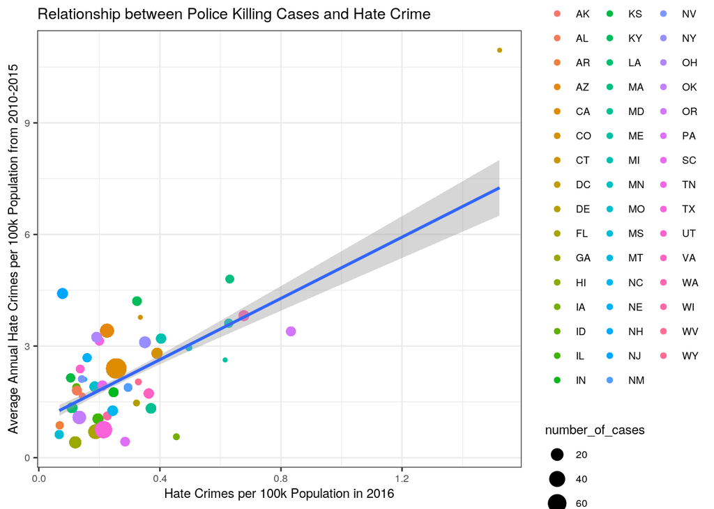

```r
library(ggplot2)
hcrimes_pkillings2 %>% ggplot(aes(hate_crimes_per_100k_splc,
    avg_hatecrimes_per_100k_fbi)) + geom_point(aes(color = state,
    size = number_of_cases)) + geom_smooth(method = "lm") + xlab("Hate Crimes per 100k Population in 2016") +
    ylab("Average Annual Hate Crimes per 100k Population from 2010-2015") +
    ggtitle("Relationship between Police Killing Cases and Hate Crime") +
    theme_bw() + theme(text = element_text(size = 9))
```

Plot 1 illustrates that most of the police killings in 2015 took place in the states which has a rate of hate crimes per 100k population of 0-0.4 and an average annual hate crime cases number per 100k population of 0-4.5 from 2010-2015.

##### Plot 2

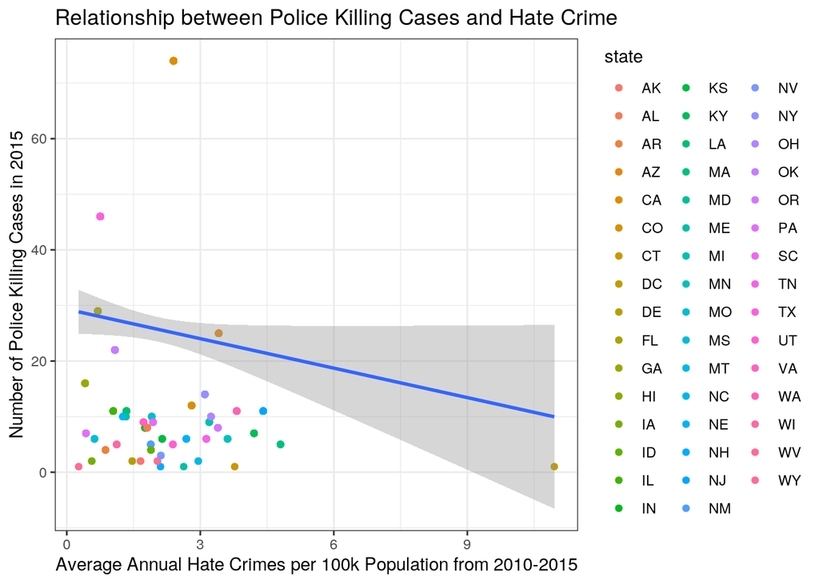

```r
hcrimes_pkillings2 %>% ggplot(aes(avg_hatecrimes_per_100k_fbi,
    number_of_cases)) + geom_point(aes(color = state)) + geom_smooth(method = "lm") +
    xlab("Average Annual Hate Crimes per 100k Population from 2010-2015") +
    ylab("Number of Police Killing Cases in 2015") + ggtitle("Relationship between Police Killing Cases and Hate Crime") +
    theme_bw()
```

Plot 2 illustrates that there was an overall negative correlation between the average annual number of hate crime from 2010-2015 and the number of police killing cases in 2015.

##### Plot 3

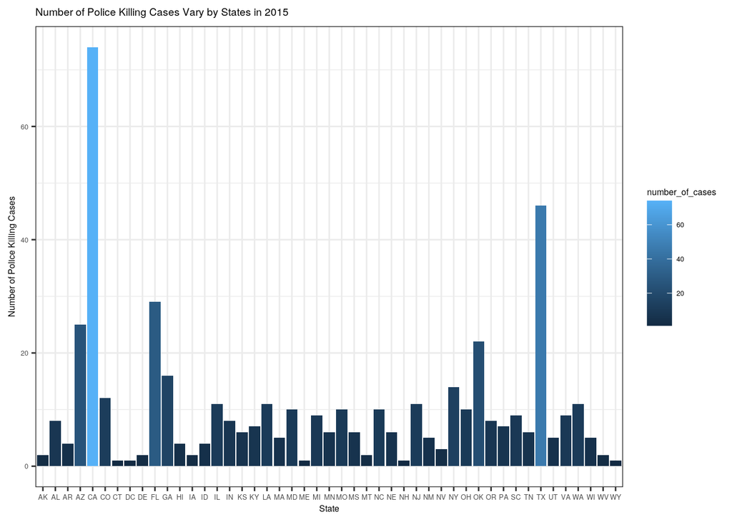

```r
hcrimes_pkillings2 %>% ggplot(aes(x = state, fill = number_of_cases)) +
    geom_bar() + theme_bw() + xlab("State") + ylab("Number of Police Killing Cases") +
    ggtitle("Number of Police Killing Cases Vary by States in 2015") +
    theme(text = element_text(size = 6))
```

Plot 3 is a bar graph that illustrates the number of cases of police killings for each state in the United States in 2015.

##### Plot 4a and 4b

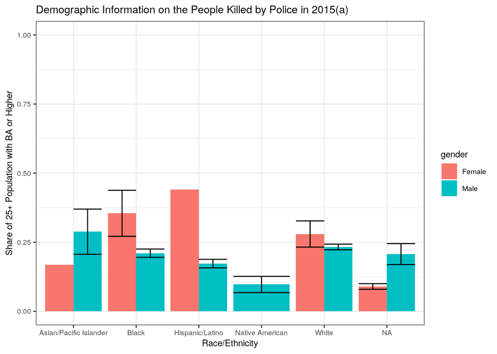

```r
ggplot(hcrimes_pkillings2, aes(x = raceethnicity, y = college,
    fill = gender)) + geom_bar(stat = "summary", position = "dodge") +
    geom_errorbar(stat = "summary", position = "dodge") + xlab("Race/Ethnicity") +
    ylab("Share of 25+ Population with BA or Higher") + ggtitle("Demographic Information on the People Killed by Police in 2015(a)") +
    ylim(0, 1) + theme_bw() + theme(text = element_text(size = 9))
```

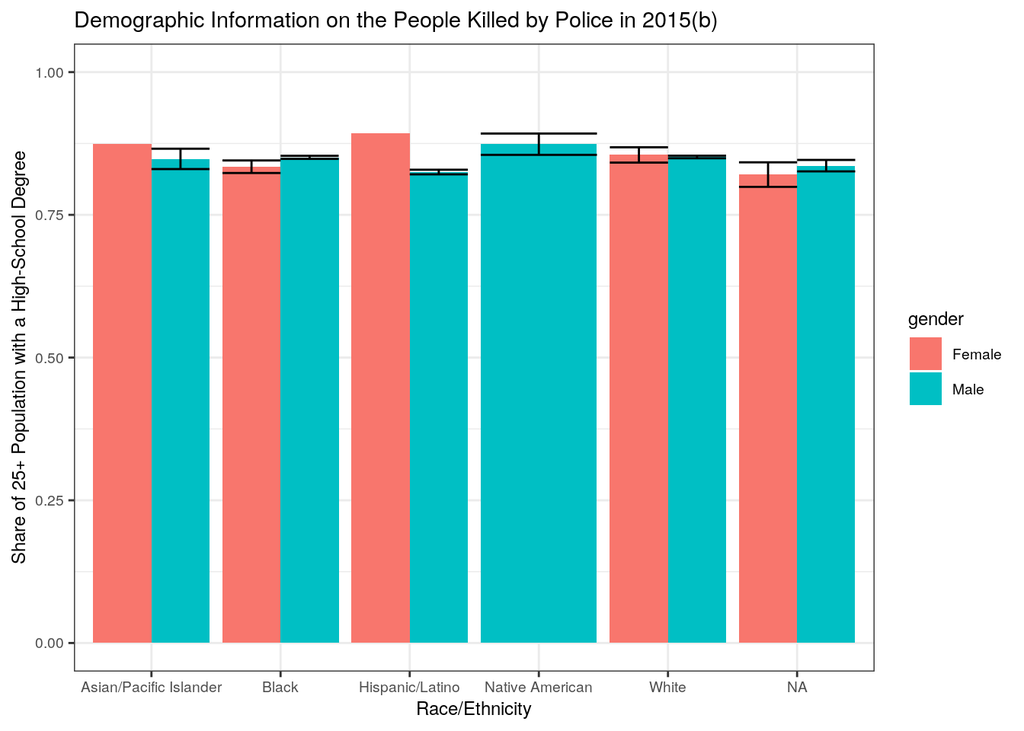

```r
ggplot(hcrimes_pkillings2, aes(x = raceethnicity, y = share_pop_hs,
    fill = gender)) + geom_bar(stat = "summary", position = "dodge") +
    geom_errorbar(stat = "summary", position = "dodge") + xlab("Race/Ethnicity") +
    ylab("Share of 25+ Population with a High-School Degree") +
    ggtitle("Demographic Information on the People Killed by Police in 2015(b)") +
    ylim(0, 1) + theme_bw() + theme(text = element_text(size = 9))
```

#### Concluding Remarks

There is a negative correlation between the number of hate crimes and the number of police killing cases. People who were killed by the police lived in a state that over 80% of the 25+ population have a high school degree or above.